# Tarea Veronica

### Lead Quality:

**Indicates the quality of lead based on the data and intuition the the employee who has been assigned to the lead**

```python
data['Lead Quality'].describe()
```

```
count         4473
unique           5
top       Might be
freq          1560
Name: Lead Quality, dtype: object
```

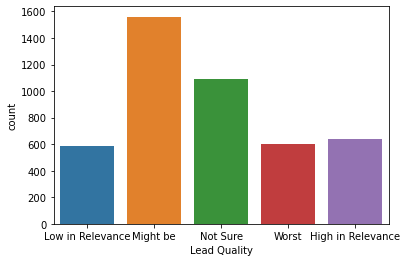

```python
sns.countplot(data['Lead Quality'])
```

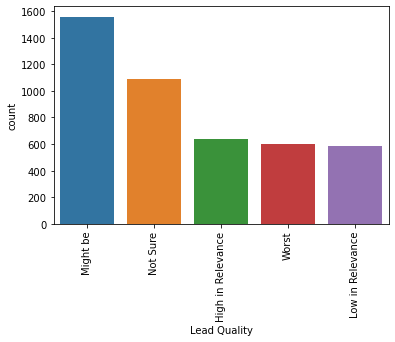

```python
lead_quality_counts = data['Lead Quality'].value_counts()

# Crea el countplot a partir de las ocurrencias contadas
sns.countplot(x='Lead Quality', data=data, order=lead_quality_counts.index)
plt.xticks(rotation=90)  # Rota las etiquetas del eje x para mayor legibilidad
plt.show()
```

```python
# As Lead quality is based on the intution of employee, so if left blank we can impute 'Not Sure' in NaN safely.
data['Lead Quality'] = data['Lead Quality'].replace(np.nan, 'Not Sure')
```

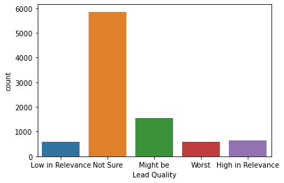

```python
sns.countplot(data['Lead Quality'])
```

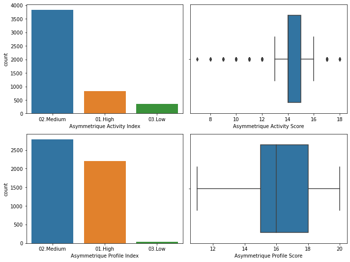

```python
fig, axs = plt.subplots(2,2, figsize = (10,7.5))

counts1 = data['Asymmetrique Activity Index'].value_counts()
plt1 = sns.countplot(x='Asymmetrique Activity Index', data=data, order=counts1.index, ax = axs[0,0])

counts2 = data['Asymmetrique Activity Score'].value_counts()
plt2 = sns.boxplot(data['Asymmetrique Activity Score'], data=data, order=counts2.index,ax = axs[0,1])

counts3 = data['Asymmetrique Profile Index'].value_counts()
plt3 = sns.countplot(data['Asymmetrique Profile Index'], data=data, order=counts3.index,ax = axs[1,0])

counts4 = data['Asymmetrique Profile Score'].value_counts()
plt4 = sns.boxplot(data['Asymmetrique Profile Score'], data=data, order=counts4.index,ax = axs[1,1])
plt.tight_layout()
```

```python
from platform import python_version

print(python_version())
```

```
3.9.7
```

**Eliminaremos ahora las columnas que contengan un 45% de valores faltantes.**

```python
data = data.drop(['Asymmetrique Activity Index','Asymmetrique Activity Score','Asymmetrique Profile Index','Asymmetrique Profile Score'],1)
```

```python
data.shape
```

```
(9240, 31)
```

```python
round(100*(data.isnull().sum()/len(data.index)), 2)
```

```
Prospect ID                                       0.00
Lead Number                                       0.00
Lead Origin                                       0.00
Lead Source                                       0.39
Do Not Email                                      0.00
Do Not Call                                       0.00
Converted                                         0.00
TotalVisits                                       1.48
Total Time Spent on Website                       0.00
Page Views Per Visit                              1.48
Last Activity                                     1.11
Country                                          26.63
Specialization                                   36.58
What is your current occupation                  29.11
What matters most to you in choosing a course    29.32
Search                                            0.00
Magazine                                          0.00
Newspaper Article                                 0.00
X Education Forums                                0.00
Newspaper                                         0.00
Digital Advertisement                             0.00
Through Recommendations                           0.00
Receive More Updates About Our Courses            0.00
Tags                                             36.29
Lead Quality                                      0.00
Update me on Supply Chain Content                 0.00
Get updates on DM Content                         0.00
City                                             39.71
I agree to pay the amount through cheque          0.00
A free copy of Mastering The Interview            0.00
Last Notable Activity                             0.00
dtype: float64
```

### City

```python
data.City.describe()
```

```
count       5571
unique         6
top       Mumbai
freq        3222
Name: City, dtype: object
```

[output not shown]

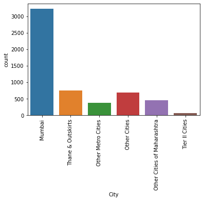

```python
sns.countplot(data.City)
xticks(rotation = 90)
```

**Around 60% of the data is Mumbai so we can impute Mumbai in the missing values.**

```python
data['City'] = data['City'].replace(np.nan, 'Mumbai')
```

### Specailization

```python
data.Specialization.describe()
```

```
count                   5860
unique                    18
top       Finance Management
freq                     976
Name: Specialization, dtype: object
```

[output not shown]

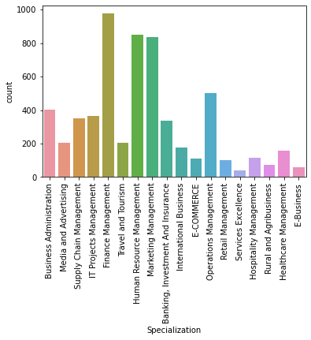

```python
sns.countplot(data.Specialization)
xticks(rotation = 90)
```

**It maybe the case that lead has not entered any specialization if his/her option is not availabe on the list, may not have any specialization or is a student. Hence we can make a category "Others" for missing values.**

```python
data['Specialization'] = data['Specialization'].replace(np.nan, 'Others')
```

```python
round(100*(data.isnull().sum()/len(data.index)), 2)
```

```
Prospect ID                                       0.00
Lead Number                                       0.00
Lead Origin                                       0.00
Lead Source                                       0.39
Do Not Email                                      0.00
Do Not Call                                       0.00
Converted                                         0.00
TotalVisits                                       1.48
Total Time Spent on Website                       0.00
Page Views Per Visit                              1.48
Last Activity                                     1.11
Country                                          26.63
Specialization                                    0.00
What is your current occupation                  29.11
What matters most to you in choosing a course    29.32
Search                                            0.00
Magazine                                          0.00
Newspaper Article                                 0.00
X Education Forums                                0.00
Newspaper                                         0.00
Digital Advertisement                             0.00
Through Recommendations                           0.00
Receive More Updates About Our Courses            0.00
Tags                                             36.29
Lead Quality                                      0.00
Update me on Supply Chain Content                 0.00
Get updates on DM Content                         0.00
City                                              0.00
I agree to pay the amount through cheque          0.00
A free copy of Mastering The Interview            0.00
Last Notable Activity                             0.00
dtype: float64
```

### Tags

```python
data.Tags.describe()
```

```
count                                    5887
unique                                     26
top       Will revert after reading the email
freq                                     2072
Name: Tags, dtype: object
```

[output not shown]

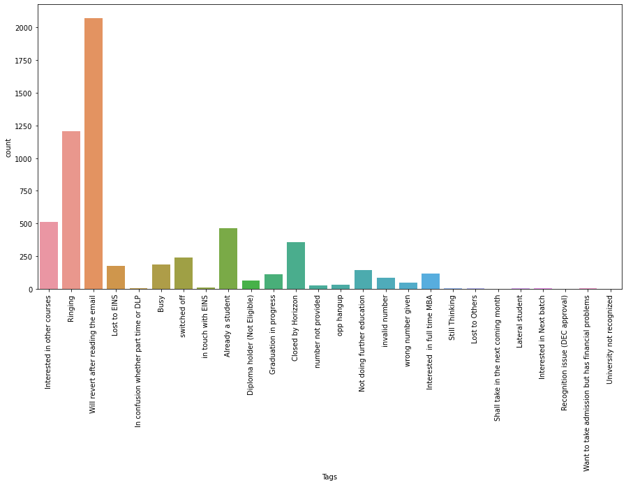

```python
fig, axs = plt.subplots(figsize = (15,7.5))
sns.countplot(data.Tags)
xticks(rotation = 90)
```

**Blanks in the tag column may be imputed by 'Will revert after reading the email'.**

```python
data['Tags'] = data['Tags'].replace(np.nan, 'Will revert after reading the email')
```

### What matters most to you in choosing a course.

```python
data['What matters most to you in choosing a course'].describe()
```

```
count                        6531
unique                          3
top       Better Career Prospects
freq                         6528
Name: What matters most to you in choosing a course, dtype: object
```

**Blanks in the this column may be imputed by 'Better Career Prospects'.**

```python
data['What matters most to you in choosing a course'] = data['What matters most to you in choosing a course'].replace(np.nan, 'Better Career Prospects')
```

### Occupation

```python
data['What is your current occupation'].describe()
```

```
count           6550
unique             6
top       Unemployed
freq            5600
Name: What is your current occupation, dtype: object
```

```python
data['What is your current occupation'] = data['What is your current occupation'].replace(np.nan, 'Unemployed')
```

### Country

```python
# Country is India for most values so let's impute the same in missing values.
data['Country'] = data['Country'].replace(np.nan, 'India')
```

```python
round(100*(data.isnull().sum()/len(data.index)), 2)
```

```
Prospect ID                                      0.00
Lead Number                                      0.00
Lead Origin                                      0.00
Lead Source                                      0.39
Do Not Email                                     0.00
Do Not Call                                      0.00
Converted                                        0.00
TotalVisits                                      1.48
Total Time Spent on Website                      0.00
Page Views Per Visit                             1.48
Last Activity                                    1.11
Country                                          0.00
Specialization                                   0.00
What is your current occupation                  0.00
What matters most to you in choosing a course    0.00
Search                                           0.00
Magazine                                         0.00
Newspaper Article                                0.00
X Education Forums                               0.00
Newspaper                                        0.00
Digital Advertisement                            0.00
Through Recommendations                          0.00
Receive More Updates About Our Courses           0.00
Tags                                             0.00
Lead Quality                                     0.00
Update me on Supply Chain Content                0.00
Get updates on DM Content                        0.00
City                                             0.00
I agree to pay the amount through cheque         0.00
A free copy of Mastering The Interview           0.00
Last Notable Activity                            0.00
dtype: float64
```

```python
# Rest missing values are under 2% so we can drop these rows.
data.dropna(inplace = True)
```

```python
round(100*(data.isnull().sum()/len(data.index)), 2)
```

```
Prospect ID                                      0.0
Lead Number                                      0.0
Lead Origin                                      0.0
Lead Source                                      0.0
Do Not Email                                     0.0
Do Not Call                                      0.0
Converted                                        0.0
TotalVisits                                      0.0
Total Time Spent on Website                      0.0
Page Views Per Visit                             0.0
Last Activity                                    0.0
Country                                          0.0
Specialization                                   0.0
What is your current occupation                  0.0
What matters most to you in choosing a course    0.0
Search                                           0.0
Magazine                                         0.0
Newspaper Article                                0.0
X Education Forums                               0.0
Newspaper                                        0.0
Digital Advertisement                            0.0
Through Recommendations                          0.0
Receive More Updates About Our Courses           0.0
Tags                                             0.0
Lead Quality                                     0.0
Update me on Supply Chain Content                0.0
Get updates on DM Content                        0.0
City                                             0.0
I agree to pay the amount through cheque         0.0
A free copy of Mastering The Interview           0.0
Last Notable Activity                            0.0
dtype: float64
```

```python
data.to_csv('Leads_cleaned')
```

# Exploratory Data Analytics

## Univariate Analysis

### Converted

Converted is the target variable, Indicates whether a lead has been successfully converted (1) or not (0).

```python
Converted = (sum(data['Converted'])/len(data['Converted'].index))*100
Converted
```

```
37.85541106458012
```

### Lead Origin

[output not shown]

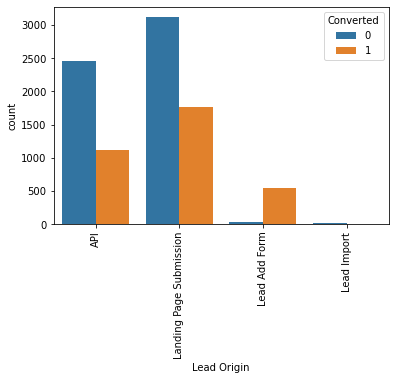

```python
sns.countplot(x = "Lead Origin", hue = "Converted", data = data)
xticks(rotation = 90)
```

### Lead Source

[output not shown]

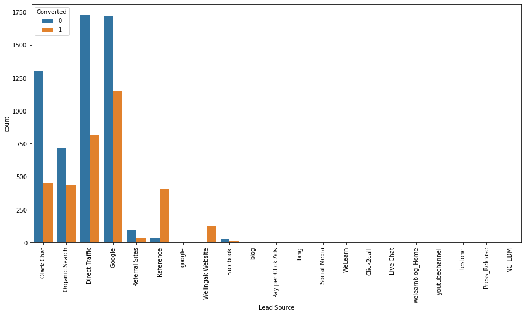

```python
fig, axs = plt.subplots(figsize = (15,7.5))
sns.countplot(x = "Lead Source", hue = "Converted", data = data)
xticks(rotation = 90)
```

```python
data['Lead Source'] = data['Lead Source'].replace(['google'], 'Google')
data['Lead Source'] = data['Lead Source'].replace(['Click2call', 'Live Chat', 'NC_EDM', 'Pay per Click Ads', 'Press_Release',
  'Social Media', 'WeLearn', 'bing', 'blog', 'testone', 'welearnblog_Home', 'youtubechannel'], 'Others')
```

[output not shown]

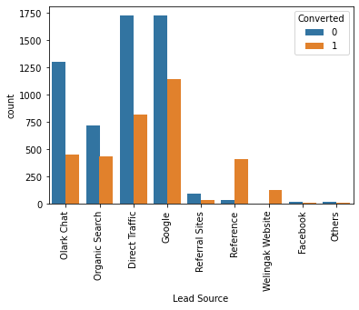

```python
sns.countplot(x = "Lead Source", hue = "Converted", data = data)
xticks(rotation = 90)
```

### Do Not Email & Do Not Call

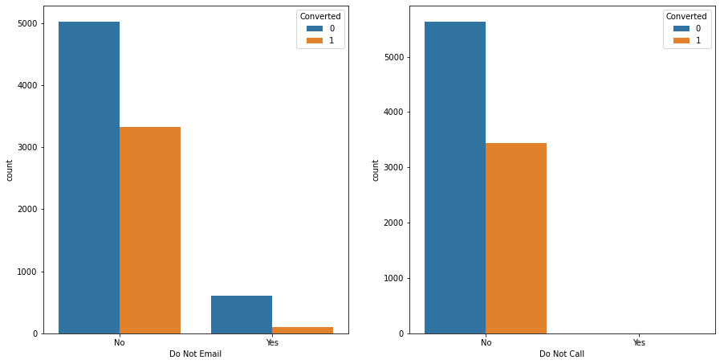

```python
fig, axs = plt.subplots(1,2,figsize = (15,7.5))
sns.countplot(x = "Do Not Email", hue = "Converted", data = data, ax = axs[0])
sns.countplot(x = "Do Not Call", hue = "Converted", data = data, ax = axs[1])
```

```python
print(data.shape)
data.head()
```

```
(9074, 31)
```

|  | Prospect ID | Lead Number | Lead Origin | Lead Source | Do Not Email | Do Not Call | Converted | TotalVisits | Total Time Spent on Website | Page Views Per Visit | Last Activity | Country | Specialization | What is your current occupation | What matters most to you in choosing a course | Search | Magazine | Newspaper Article | X Education Forums | Newspaper | Digital Advertisement | Through Recommendations | Receive More Updates About Our Courses | Tags | Lead Quality | Update me on Supply Chain Content | Get updates on DM Content | City | I agree to pay the amount through cheque | … |
| --- | --- | --- | --- | --- | --- | --- | --- | --- | --- | --- | --- | --- | --- | --- | --- | --- | --- | --- | --- | --- | --- | --- | --- | --- | --- | --- | --- | --- | --- | --- |
| 0 | 7927b2df-8bba-4d29-b9a2-b6e0beafe620 | 660737 | API | Olark Chat | No | No | 0 | 0.0 | 0 | 0.0 | Page Visited on Website | India | Others | Unemployed | Better Career Prospects | No | No | No | No | No | No | No | No | Interested in other courses | Low in Relevance | No | No | Mumbai | No | … |
| 1 | 2a272436-5132-4136-86fa-dcc88c88f482 | 660728 | API | Organic Search | No | No | 0 | 5.0 | 674 | 2.5 | Email Opened | India | Others | Unemployed | Better Career Prospects | No | No | No | No | No | No | No | No | Ringing | Not Sure | No | No | Mumbai | No | … |
| 2 | 8cc8c611-a219-4f35-ad23-fdfd2656bd8a | 660727 | Landing Page Submission | Direct Traffic | No | No | 1 | 2.0 | 1532 | 2.0 | Email Opened | India | Business Administration | Student | Better Career Prospects | No | No | No | No | No | No | No | No | Will revert after reading the email | Might be | No | No | Mumbai | No | … |
| 3 | 0cc2df48-7cf4-4e39-9de9-19797f9b38cc | 660719 | Landing Page Submission | Direct Traffic | No | No | 0 | 1.0 | 305 | 1.0 | Unreachable | India | Media and Advertising | Unemployed | Better Career Prospects | No | No | No | No | No | No | No | No | Ringing | Not Sure | No | No | Mumbai | No | … |
| 4 | 3256f628-e534-4826-9d63-4a8b88782852 | 660681 | Landing Page Submission | Google | No | No | 1 | 2.0 | 1428 | 1.0 | Converted to Lead | India | Others | Unemployed | Better Career Prospects | No | No | No | No | No | No | No | No | Will revert after reading the email | Might be | No | No | Mumbai | No | … |

##### Results

**Based on the univariate analysis we have seen that many columns are not adding any information to the model, heance we can drop them for frther analysis.**

```python
data = data.drop(['Lead Number','What matters most to you in choosing a course','Search','Magazine','Newspaper Article','X Education Forums','Newspaper',
           'Digital Advertisement','Through Recommendations','Receive More Updates About Our Courses','Update me on Supply Chain Content',
           'Get updates on DM Content','I agree to pay the amount through cheque','A free copy of Mastering The Interview','Country'],1)
```

```python
data.shape
```

```
(9074, 16)
```

```python
data.head()
```

[output not shown]

### Data Preparation

Converting some binary variables (Yes/No) to 1/0

```python
# List of variables to map

varlist =  ['Do Not Email', 'Do Not Call']

# Defining the map function
def binary_map(x):
    return x.map({'Yes': 1, "No": 0})

# Applying the function to the housing list
data[varlist] = data[varlist].apply(binary_map)
```

For categorical variables with multiple levels, create dummy features (one-hot encoded)

```python
# Creating a dummy variable for some of the categorical variables and dropping the first one.
dummy1 = pd.get_dummies(data[['Lead Origin', 'Lead Source', 'Last Activity', 'Specialization','What is your current occupation',
                              'Tags','Lead Quality','City','Last Notable Activity']], drop_first=True)
dummy1.head()
```

|  | Lead Origin_Landing Page Submission | Lead Origin_Lead Add Form | Lead Origin_Lead Import | Lead Source_Facebook | Lead Source_Google | Lead Source_Olark Chat | Lead Source_Organic Search | Lead Source_Others | Lead Source_Reference | Lead Source_Referral Sites | Lead Source_Welingak Website | Last Activity_Converted to Lead | Last Activity_Email Bounced | Last Activity_Email Link Clicked | Last Activity_Email Marked Spam | Last Activity_Email Opened | Last Activity_Email Received | Last Activity_Form Submitted on Website | Last Activity_Had a Phone Conversation | Last Activity_Olark Chat Conversation | Last Activity_Page Visited on Website | Last Activity_Resubscribed to emails | Last Activity_SMS Sent | Last Activity_Unreachable | Last Activity_Unsubscribed | Last Activity_View in browser link Clicked | Last Activity_Visited Booth in Tradeshow | Specialization_Business Administration | Specialization_E-Business | … |
| --- | --- | --- | --- | --- | --- | --- | --- | --- | --- | --- | --- | --- | --- | --- | --- | --- | --- | --- | --- | --- | --- | --- | --- | --- | --- | --- | --- | --- | --- | --- |
| 0 | 0 | 0 | 0 | 0 | 0 | 1 | 0 | 0 | 0 | 0 | 0 | 0 | 0 | 0 | 0 | 0 | 0 | 0 | 0 | 0 | 1 | 0 | 0 | 0 | 0 | 0 | 0 | 0 | 0 | … |
| 1 | 0 | 0 | 0 | 0 | 0 | 0 | 1 | 0 | 0 | 0 | 0 | 0 | 0 | 0 | 0 | 1 | 0 | 0 | 0 | 0 | 0 | 0 | 0 | 0 | 0 | 0 | 0 | 0 | 0 | … |
| 2 | 1 | 0 | 0 | 0 | 0 | 0 | 0 | 0 | 0 | 0 | 0 | 0 | 0 | 0 | 0 | 1 | 0 | 0 | 0 | 0 | 0 | 0 | 0 | 0 | 0 | 0 | 0 | 1 | 0 | … |
| 3 | 1 | 0 | 0 | 0 | 0 | 0 | 0 | 0 | 0 | 0 | 0 | 0 | 0 | 0 | 0 | 0 | 0 | 0 | 0 | 0 | 0 | 0 | 0 | 1 | 0 | 0 | 0 | 0 | 0 | … |
| 4 | 1 | 0 | 0 | 0 | 1 | 0 | 0 | 0 | 0 | 0 | 0 | 1 | 0 | 0 | 0 | 0 | 0 | 0 | 0 | 0 | 0 | 0 | 0 | 0 | 0 | 0 | 0 | 0 | 0 | … |

```python
# Adding the results to the master dataframe
data = pd.concat([data, dummy1], axis=1)
data.head()
```

|  | Prospect ID | Lead Origin | Lead Source | Do Not Email | Do Not Call | Converted | TotalVisits | Total Time Spent on Website | Page Views Per Visit | Last Activity | Specialization | What is your current occupation | Tags | Lead Quality | City | Last Notable Activity | Lead Origin_Landing Page Submission | Lead Origin_Lead Add Form | Lead Origin_Lead Import | Lead Source_Facebook | Lead Source_Google | Lead Source_Olark Chat | Lead Source_Organic Search | Lead Source_Others | Lead Source_Reference | Lead Source_Referral Sites | Lead Source_Welingak Website | Last Activity_Converted to Lead | Last Activity_Email Bounced | … |
| --- | --- | --- | --- | --- | --- | --- | --- | --- | --- | --- | --- | --- | --- | --- | --- | --- | --- | --- | --- | --- | --- | --- | --- | --- | --- | --- | --- | --- | --- | --- |
| 0 | 7927b2df-8bba-4d29-b9a2-b6e0beafe620 | API | Olark Chat | 0 | 0 | 0 | 0.0 | 0 | 0.0 | Page Visited on Website | Others | Unemployed | Interested in other courses | Low in Relevance | Mumbai | Modified | 0 | 0 | 0 | 0 | 0 | 1 | 0 | 0 | 0 | 0 | 0 | 0 | 0 | … |
| 1 | 2a272436-5132-4136-86fa-dcc88c88f482 | API | Organic Search | 0 | 0 | 0 | 5.0 | 674 | 2.5 | Email Opened | Others | Unemployed | Ringing | Not Sure | Mumbai | Email Opened | 0 | 0 | 0 | 0 | 0 | 0 | 1 | 0 | 0 | 0 | 0 | 0 | 0 | … |
| 2 | 8cc8c611-a219-4f35-ad23-fdfd2656bd8a | Landing Page Submission | Direct Traffic | 0 | 0 | 1 | 2.0 | 1532 | 2.0 | Email Opened | Business Administration | Student | Will revert after reading the email | Might be | Mumbai | Email Opened | 1 | 0 | 0 | 0 | 0 | 0 | 0 | 0 | 0 | 0 | 0 | 0 | 0 | … |
| 3 | 0cc2df48-7cf4-4e39-9de9-19797f9b38cc | Landing Page Submission | Direct Traffic | 0 | 0 | 0 | 1.0 | 305 | 1.0 | Unreachable | Media and Advertising | Unemployed | Ringing | Not Sure | Mumbai | Modified | 1 | 0 | 0 | 0 | 0 | 0 | 0 | 0 | 0 | 0 | 0 | 0 | 0 | … |
| 4 | 3256f628-e534-4826-9d63-4a8b88782852 | Landing Page Submission | Google | 0 | 0 | 1 | 2.0 | 1428 | 1.0 | Converted to Lead | Others | Unemployed | Will revert after reading the email | Might be | Mumbai | Modified | 1 | 0 | 0 | 0 | 1 | 0 | 0 | 0 | 0 | 0 | 0 | 1 | 0 | … |

5 rows × 115 columns

```python
data = data.drop(['Lead Origin', 'Lead Source', 'Last Activity', 'Specialization','What is your current occupation','Tags','Lead Quality','City','Last Notable Activity'], axis = 1)
data.head()
```

|  | Prospect ID | Do Not Email | Do Not Call | Converted | TotalVisits | Total Time Spent on Website | Page Views Per Visit | Lead Origin_Landing Page Submission | Lead Origin_Lead Add Form | Lead Origin_Lead Import | Lead Source_Facebook | Lead Source_Google | Lead Source_Olark Chat | Lead Source_Organic Search | Lead Source_Others | Lead Source_Reference | Lead Source_Referral Sites | Lead Source_Welingak Website | Last Activity_Converted to Lead | Last Activity_Email Bounced | Last Activity_Email Link Clicked | Last Activity_Email Marked Spam | Last Activity_Email Opened | Last Activity_Email Received | Last Activity_Form Submitted on Website | Last Activity_Had a Phone Conversation | Last Activity_Olark Chat Conversation | Last Activity_Page Visited on Website | Last Activity_Resubscribed to emails | … |
| --- | --- | --- | --- | --- | --- | --- | --- | --- | --- | --- | --- | --- | --- | --- | --- | --- | --- | --- | --- | --- | --- | --- | --- | --- | --- | --- | --- | --- | --- | --- |
| 0 | 7927b2df-8bba-4d29-b9a2-b6e0beafe620 | 0 | 0 | 0 | 0.0 | 0 | 0.0 | 0 | 0 | 0 | 0 | 0 | 1 | 0 | 0 | 0 | 0 | 0 | 0 | 0 | 0 | 0 | 0 | 0 | 0 | 0 | 0 | 1 | 0 | … |
| 1 | 2a272436-5132-4136-86fa-dcc88c88f482 | 0 | 0 | 0 | 5.0 | 674 | 2.5 | 0 | 0 | 0 | 0 | 0 | 0 | 1 | 0 | 0 | 0 | 0 | 0 | 0 | 0 | 0 | 1 | 0 | 0 | 0 | 0 | 0 | 0 | … |
| 2 | 8cc8c611-a219-4f35-ad23-fdfd2656bd8a | 0 | 0 | 1 | 2.0 | 1532 | 2.0 | 1 | 0 | 0 | 0 | 0 | 0 | 0 | 0 | 0 | 0 | 0 | 0 | 0 | 0 | 0 | 1 | 0 | 0 | 0 | 0 | 0 | 0 | … |
| 3 | 0cc2df48-7cf4-4e39-9de9-19797f9b38cc | 0 | 0 | 0 | 1.0 | 305 | 1.0 | 1 | 0 | 0 | 0 | 0 | 0 | 0 | 0 | 0 | 0 | 0 | 0 | 0 | 0 | 0 | 0 | 0 | 0 | 0 | 0 | 0 | 0 | … |
| 4 | 3256f628-e534-4826-9d63-4a8b88782852 | 0 | 0 | 1 | 2.0 | 1428 | 1.0 | 1 | 0 | 0 | 0 | 1 | 0 | 0 | 0 | 0 | 0 | 0 | 1 | 0 | 0 | 0 | 0 | 0 | 0 | 0 | 0 | 0 | 0 | … |

5 rows × 106 columns

```python
from sklearn.model_selection import train_test_split

# Putting feature variable to X
X = data.drop(['Prospect ID','Converted'], axis=1)
```

```python
X.head()
```

|  | Do Not Email | Do Not Call | TotalVisits | Total Time Spent on Website | Page Views Per Visit | Lead Origin_Landing Page Submission | Lead Origin_Lead Add Form | Lead Origin_Lead Import | Lead Source_Facebook | Lead Source_Google | Lead Source_Olark Chat | Lead Source_Organic Search | Lead Source_Others | Lead Source_Reference | Lead Source_Referral Sites | Lead Source_Welingak Website | Last Activity_Converted to Lead | Last Activity_Email Bounced | Last Activity_Email Link Clicked | Last Activity_Email Marked Spam | Last Activity_Email Opened | Last Activity_Email Received | Last Activity_Form Submitted on Website | Last Activity_Had a Phone Conversation | Last Activity_Olark Chat Conversation | Last Activity_Page Visited on Website | Last Activity_Resubscribed to emails | Last Activity_SMS Sent | Last Activity_Unreachable | … |
| --- | --- | --- | --- | --- | --- | --- | --- | --- | --- | --- | --- | --- | --- | --- | --- | --- | --- | --- | --- | --- | --- | --- | --- | --- | --- | --- | --- | --- | --- | --- |
| 0 | 0 | 0 | 0.0 | 0 | 0.0 | 0 | 0 | 0 | 0 | 0 | 1 | 0 | 0 | 0 | 0 | 0 | 0 | 0 | 0 | 0 | 0 | 0 | 0 | 0 | 0 | 1 | 0 | 0 | 0 | … |
| 1 | 0 | 0 | 5.0 | 674 | 2.5 | 0 | 0 | 0 | 0 | 0 | 0 | 1 | 0 | 0 | 0 | 0 | 0 | 0 | 0 | 0 | 1 | 0 | 0 | 0 | 0 | 0 | 0 | 0 | 0 | … |
| 2 | 0 | 0 | 2.0 | 1532 | 2.0 | 1 | 0 | 0 | 0 | 0 | 0 | 0 | 0 | 0 | 0 | 0 | 0 | 0 | 0 | 0 | 1 | 0 | 0 | 0 | 0 | 0 | 0 | 0 | 0 | … |
| 3 | 0 | 0 | 1.0 | 305 | 1.0 | 1 | 0 | 0 | 0 | 0 | 0 | 0 | 0 | 0 | 0 | 0 | 0 | 0 | 0 | 0 | 0 | 0 | 0 | 0 | 0 | 0 | 0 | 0 | 1 | … |
| 4 | 0 | 0 | 2.0 | 1428 | 1.0 | 1 | 0 | 0 | 0 | 1 | 0 | 0 | 0 | 0 | 0 | 0 | 1 | 0 | 0 | 0 | 0 | 0 | 0 | 0 | 0 | 0 | 0 | 0 | 0 | … |

5 rows × 104 columns

```python
# Putting response variable to y
y = data['Converted']

y.head()
```

```
0    0
1    0
2    1
3    0
4    1
Name: Converted, dtype: int64
```

```python
# Splitting the data into train and test
X_train, X_test, y_train, y_test = train_test_split(X, y, train_size=0.7, test_size=0.3, random_state=100)
```

```python
from sklearn.preprocessing import StandardScaler

scaler = StandardScaler()

X_train[['TotalVisits','Total Time Spent on Website','Page Views Per Visit']] = scaler.fit_transform(X_train[['TotalVisits','Total Time Spent on Website','Page Views Per Visit']])

X_train.head()
```

|  | Do Not Email | Do Not Call | TotalVisits | Total Time Spent on Website | Page Views Per Visit | Lead Origin_Landing Page Submission | Lead Origin_Lead Add Form | Lead Origin_Lead Import | Lead Source_Facebook | Lead Source_Google | Lead Source_Olark Chat | Lead Source_Organic Search | Lead Source_Others | Lead Source_Reference | Lead Source_Referral Sites | Lead Source_Welingak Website | Last Activity_Converted to Lead | Last Activity_Email Bounced | Last Activity_Email Link Clicked | Last Activity_Email Marked Spam | Last Activity_Email Opened | Last Activity_Email Received | Last Activity_Form Submitted on Website | Last Activity_Had a Phone Conversation | Last Activity_Olark Chat Conversation | Last Activity_Page Visited on Website | Last Activity_Resubscribed to emails | Last Activity_SMS Sent | Last Activity_Unreachable | … |
| --- | --- | --- | --- | --- | --- | --- | --- | --- | --- | --- | --- | --- | --- | --- | --- | --- | --- | --- | --- | --- | --- | --- | --- | --- | --- | --- | --- | --- | --- | --- |
| 3009 | 0 | 0 | -0.284595 | -0.160255 | -0.179666 | 1 | 0 | 0 | 0 | 0 | 0 | 0 | 0 | 0 | 0 | 0 | 0 | 0 | 0 | 0 | 1 | 0 | 0 | 0 | 0 | 0 | 0 | 0 | 0 | … |
| 1012 | 1 | 0 | -0.284595 | -0.540048 | -0.179666 | 1 | 0 | 0 | 0 | 0 | 0 | 0 | 0 | 0 | 0 | 0 | 0 | 1 | 0 | 0 | 0 | 0 | 0 | 0 | 0 | 0 | 0 | 0 | 0 | … |
| 9226 | 0 | 0 | -0.671384 | -0.888650 | -1.132538 | 0 | 0 | 0 | 0 | 0 | 1 | 0 | 0 | 0 | 0 | 0 | 0 | 0 | 0 | 0 | 0 | 0 | 0 | 0 | 0 | 0 | 0 | 1 | 0 | … |
| 4750 | 0 | 0 | -0.284595 | 1.643304 | -0.179666 | 1 | 0 | 0 | 0 | 0 | 0 | 0 | 0 | 0 | 0 | 0 | 0 | 0 | 0 | 0 | 0 | 0 | 0 | 0 | 0 | 0 | 0 | 1 | 0 | … |
| 7987 | 0 | 0 | 0.295588 | 2.017593 | 0.058552 | 1 | 0 | 0 | 0 | 0 | 0 | 0 | 0 | 0 | 0 | 0 | 0 | 0 | 0 | 0 | 0 | 0 | 0 | 0 | 0 | 0 | 0 | 1 | 0 | … |

5 rows × 104 columns

```python
# Checking the Churn Rate
Converted = (sum(data['Converted'])/len(data['Converted'].index))*100
Converted
```

```
37.85541106458012
```

### Model Building

Running Your First Training Model

```python
import statsmodels.api as sm
```

```python
# Logistic regression model
logm1 = sm.GLM(y_train,(sm.add_constant(X_train)), family = sm.families.Binomial())
logm1.fit().summary()
```

Generalized Linear Model Regression Results

| Dep. Variable: | Converted | No. Observations: | 6351 |
| --- | --- | --- | --- |
| Model: | GLM | Df Residuals: | 6248 |
| Model Family: | Binomial | Df Model: | 102 |
| Link Function: | logit | Scale: | 1.0000 |
| Method: | IRLS | Log-Likelihood: | -1237.2 |
| Date: | Fri, 25 Aug 2023 | Deviance: | 2474.4 |
| Time: | 18:06:43 | Pearson chi2: | 3.66e+04 |
| No. Iterations: | 24 |  |  |
| Covariance Type: | nonrobust |  |  |

|  | coef | std err | z | P>\|z\| | [0.025 | 0.975] |
| --- | --- | --- | --- | --- | --- | --- |
| const | 24.3058 | 2.19e+05 | 0.000 | 1.000 | -4.29e+05 | 4.29e+05 |
| Do Not Email | -1.4782 | 0.334 | -4.422 | 0.000 | -2.133 | -0.823 |
| Do Not Call | 23.8191 | 1.36e+05 | 0.000 | 1.000 | -2.67e+05 | 2.67e+05 |
| TotalVisits | 0.1611 | 0.036 | 4.429 | 0.000 | 0.090 | 0.232 |
| Total Time Spent on Website | 1.1488 | 0.064 | 17.870 | 0.000 | 1.023 | 1.275 |
| Page Views Per Visit | -0.1582 | 0.074 | -2.148 | 0.032 | -0.303 | -0.014 |
| Lead Origin_Landing Page Submission | -1.0249 | 0.223 | -4.606 | 0.000 | -1.461 | -0.589 |
| Lead Origin_Lead Add Form | -0.2415 | 1.330 | -0.181 | 0.856 | -2.849 | 2.366 |
| Lead Origin_Lead Import | 29.8727 | 2.08e+05 | 0.000 | 1.000 | -4.07e+05 | 4.07e+05 |
| Lead Source_Facebook | -28.6509 | 2.08e+05 | -0.000 | 1.000 | -4.07e+05 | 4.07e+05 |
| Lead Source_Google | 0.1843 | 0.155 | 1.186 | 0.236 | -0.120 | 0.489 |
| Lead Source_Olark Chat | 0.9945 | 0.228 | 4.365 | 0.000 | 0.548 | 1.441 |
| Lead Source_Organic Search | 0.1513 | 0.210 | 0.720 | 0.471 | -0.261 | 0.563 |
| Lead Source_Others | 0.8169 | 0.812 | 1.006 | 0.314 | -0.775 | 2.408 |
| Lead Source_Reference | 1.8341 | 1.391 | 1.319 | 0.187 | -0.892 | 4.560 |
| Lead Source_Referral Sites | -0.1439 | 0.490 | -0.293 | 0.769 | -1.105 | 0.817 |
| Lead Source_Welingak Website | 5.4505 | 1.526 | 3.571 | 0.000 | 2.459 | 8.442 |
| Last Activity_Converted to Lead | -19.1909 | 9.63e+04 | -0.000 | 1.000 | -1.89e+05 | 1.89e+05 |
| Last Activity_Email Bounced | -19.5269 | 9.63e+04 | -0.000 | 1.000 | -1.89e+05 | 1.89e+05 |
| Last Activity_Email Link Clicked | -18.3726 | 9.63e+04 | -0.000 | 1.000 | -1.89e+05 | 1.89e+05 |
| Last Activity_Email Marked Spam | 0.3186 | 1.28e+05 | 2.49e-06 | 1.000 | -2.5e+05 | 2.5e+05 |
| Last Activity_Email Opened | -19.2023 | 9.63e+04 | -0.000 | 1.000 | -1.89e+05 | 1.89e+05 |
| Last Activity_Email Received | 3.1686 | 2.62e+05 | 1.21e-05 | 1.000 | -5.13e+05 | 5.13e+05 |
| Last Activity_Form Submitted on Website | -19.0374 | 9.63e+04 | -0.000 | 1.000 | -1.89e+05 | 1.89e+05 |
| Last Activity_Had a Phone Conversation | -16.3250 | 9.63e+04 | -0.000 | 1.000 | -1.89e+05 | 1.89e+05 |
| Last Activity_Olark Chat Conversation | -19.7388 | 9.63e+04 | -0.000 | 1.000 | -1.89e+05 | 1.89e+05 |
| Last Activity_Page Visited on Website | -18.6907 | 9.63e+04 | -0.000 | 1.000 | -1.89e+05 | 1.89e+05 |
| Last Activity_Resubscribed to emails | -0.9141 | 1.49e+05 | -6.15e-06 | 1.000 | -2.91e+05 | 2.91e+05 |
| Last Activity_SMS Sent | -18.0849 | 9.63e+04 | -0.000 | 1.000 | -1.89e+05 | 1.89e+05 |
| Last Activity_Unreachable | -18.4747 | 9.63e+04 | -0.000 | 1.000 | -1.89e+05 | 1.89e+05 |

[output cut: 75 more lines]

### Feature Selection Using RFE

```python
from sklearn.linear_model import LogisticRegression
logreg = LogisticRegression()

from sklearn.feature_selection import RFE
rfe = RFE(logreg, 15)             # running RFE with 15 variables as output
rfe = rfe.fit(X_train, y_train)
```

```python
rfe.support_
```

```
array([ True, False, False, False, False, False,  True, False, False,
       False, False, False, False, False, False,  True, False, False,
       False, False, False, False, False, False, False, False, False,
       False, False, False, False, False, False, False, False, False,
       False, False, False, False, False, False, False, False, False,
       False, False, False, False, False, False, False, False, False,
       False,  True,  True, False, False, False, False, False, False,
       False,  True, False, False, False,  True, False, False, False,
       False,  True, False,  True,  True, False,  True,  True, False,
       False,  True,  True, False, False, False, False, False, False,
       False, False, False, False, False, False, False, False, False,
       False,  True, False, False, False])
```

```python
list(zip(X_train.columns, rfe.support_, rfe.ranking_))
```

```
[('Do Not Email', True, 1),
 ('Do Not Call', False, 44),
 ('TotalVisits', False, 55),
 ('Total Time Spent on Website', False, 4),
 ('Page Views Per Visit', False, 57),
 ('Lead Origin_Landing Page Submission', False, 21),
 ('Lead Origin_Lead Add Form', True, 1),
 ('Lead Origin_Lead Import', False, 3),
 ('Lead Source_Facebook', False, 56),
 ('Lead Source_Google', False, 60),
 ('Lead Source_Olark Chat', False, 6),
 ('Lead Source_Organic Search', False, 61),
 ('Lead Source_Others', False, 58),
 ('Lead Source_Reference', False, 82),
 ('Lead Source_Referral Sites', False, 45),
 ('Lead Source_Welingak Website', True, 1),
 ('Last Activity_Converted to Lead', False, 43),
 ('Last Activity_Email Bounced', False, 39),
 ('Last Activity_Email Link Clicked', False, 81),
 ('Last Activity_Email Marked Spam', False, 53),
 ('Last Activity_Email Opened', False, 47),
 ('Last Activity_Email Received', False, 80),
 ('Last Activity_Form Submitted on Website', False, 51),
 ('Last Activity_Had a Phone Conversation', False, 16),
 ('Last Activity_Olark Chat Conversation', False, 18),
 ('Last Activity_Page Visited on Website', False, 89),
 ('Last Activity_Resubscribed to emails', False, 77),
 ('Last Activity_SMS Sent', False, 8),
 ('Last Activity_Unreachable', False, 19),
 ('Last Activity_Unsubscribed', False, 24),
 ('Last Activity_View in browser link Clicked', False, 40),
 ('Last Activity_Visited Booth in Tradeshow', False, 90),
 ('Specialization_Business Administration', False, 86),
 ('Specialization_E-Business', False, 85),
 ('Specialization_E-COMMERCE', False, 20),
 ('Specialization_Finance Management', False, 50),
 ('Specialization_Healthcare Management', False, 49),
 ('Specialization_Hospitality Management', False, 83),
 ('Specialization_Human Resource Management', False, 59),
 ('Specialization_IT Projects Management', False, 71),
```

[output cut: 49 more lines]

```
 ('Last Notable Activity_Email Bounced', False, 32),
 ('Last Notable Activity_Email Link Clicked', False, 17),
 ('Last Notable Activity_Email Marked Spam', False, 54),
 ('Last Notable Activity_Email Opened', False, 68),
 ('Last Notable Activity_Email Received', False, 88),
 ('Last Notable Activity_Form Submitted on Website', False, 62),
 ('Last Notable Activity_Had a Phone Conversation', False, 34),
 ('Last Notable Activity_Modified', False, 7),
 ('Last Notable Activity_Olark Chat Conversation', False, 5),
 ('Last Notable Activity_Page Visited on Website', False, 28),
 ('Last Notable Activity_Resubscribed to emails', False, 75),
 ('Last Notable Activity_SMS Sent', True, 1),
 ('Last Notable Activity_Unreachable', False, 38),
 ('Last Notable Activity_Unsubscribed', False, 42),
 ('Last Notable Activity_View in browser link Clicked', False, 87)]
```

```python
col = X_train.columns[rfe.support_]
col
```

```
Index(['Do Not Email', 'Lead Origin_Lead Add Form',
       'Lead Source_Welingak Website', 'Tags_Busy', 'Tags_Closed by Horizzon',
       'Tags_Lost to EINS', 'Tags_Ringing',
       'Tags_Will revert after reading the email', 'Tags_invalid number',
       'Tags_number not provided', 'Tags_switched off',
       'Tags_wrong number given', 'Lead Quality_Not Sure',
       'Lead Quality_Worst', 'Last Notable Activity_SMS Sent'],
      dtype='object')
```

```python
X_train.columns[~rfe.support_]
```

```
Index(['Do Not Call', 'TotalVisits', 'Total Time Spent on Website',
       'Page Views Per Visit', 'Lead Origin_Landing Page Submission',
       'Lead Origin_Lead Import', 'Lead Source_Facebook', 'Lead Source_Google',
       'Lead Source_Olark Chat', 'Lead Source_Organic Search',
       'Lead Source_Others', 'Lead Source_Reference',
       'Lead Source_Referral Sites', 'Last Activity_Converted to Lead',
       'Last Activity_Email Bounced', 'Last Activity_Email Link Clicked',
       'Last Activity_Email Marked Spam', 'Last Activity_Email Opened',
       'Last Activity_Email Received',
       'Last Activity_Form Submitted on Website',
       'Last Activity_Had a Phone Conversation',
       'Last Activity_Olark Chat Conversation',
       'Last Activity_Page Visited on Website',
       'Last Activity_Resubscribed to emails', 'Last Activity_SMS Sent',
       'Last Activity_Unreachable', 'Last Activity_Unsubscribed',
       'Last Activity_View in browser link Clicked',
       'Last Activity_Visited Booth in Tradeshow',
       'Specialization_Business Administration', 'Specialization_E-Business',
       'Specialization_E-COMMERCE', 'Specialization_Finance Management',
       'Specialization_Healthcare Management',
       'Specialization_Hospitality Management',
       'Specialization_Human Resource Management',
       'Specialization_IT Projects Management',
       'Specialization_International Business',
       'Specialization_Marketing Management',
       'Specialization_Media and Advertising',
       'Specialization_Operations Management', 'Specialization_Others',
       'Specialization_Retail Management',
       'Specialization_Rural and Agribusiness',
       'Specialization_Services Excellence',
       'Specialization_Supply Chain Management',
       'Specialization_Travel and Tourism',
       'What is your current occupation_Housewife',
       'What is your current occupation_Other',
       'What is your current occupation_Student',
       'What is your current occupation_Unemployed',
       'What is your current occupation_Working Professional',
       'Tags_Diploma holder (Not Eligible)', 'Tags_Graduation in progress',
       'Tags_In confusion whether part time or DLP',
       'Tags_Interested  in full time MBA', 'Tags_Interested in Next batch',
```

[output cut: 10 more lines]

```
       'City_Tier II Cities', 'Last Notable Activity_Email Bounced',
       'Last Notable Activity_Email Link Clicked',
       'Last Notable Activity_Email Marked Spam',
       'Last Notable Activity_Email Opened',
       'Last Notable Activity_Email Received',
       'Last Notable Activity_Form Submitted on Website',
       'Last Notable Activity_Had a Phone Conversation',
       'Last Notable Activity_Modified',
       'Last Notable Activity_Olark Chat Conversation',
       'Last Notable Activity_Page Visited on Website',
       'Last Notable Activity_Resubscribed to emails',
       'Last Notable Activity_Unreachable',
       'Last Notable Activity_Unsubscribed',
       'Last Notable Activity_View in browser link Clicked'],
      dtype='object')
```

```python
X_train_sm = sm.add_constant(X_train[col])
logm2 = sm.GLM(y_train,X_train_sm, family = sm.families.Binomial())
res = logm2.fit()
res.summary()
```

Generalized Linear Model Regression Results

| Dep. Variable: | Converted | No. Observations: | 6351 |
| --- | --- | --- | --- |
| Model: | GLM | Df Residuals: | 6335 |
| Model Family: | Binomial | Df Model: | 15 |
| Link Function: | logit | Scale: | 1.0000 |
| Method: | IRLS | Log-Likelihood: | -1588.2 |
| Date: | Fri, 25 Aug 2023 | Deviance: | 3176.4 |
| Time: | 18:11:12 | Pearson chi2: | 3.57e+04 |
| No. Iterations: | 24 |  |  |
| Covariance Type: | nonrobust |  |  |

|  | coef | std err | z | P>\|z\| | [0.025 | 0.975] |
| --- | --- | --- | --- | --- | --- | --- |
| const | -1.5851 | 0.207 | -7.673 | 0.000 | -1.990 | -1.180 |
| Do Not Email | -1.2714 | 0.214 | -5.946 | 0.000 | -1.690 | -0.852 |
| Lead Origin_Lead Add Form | 1.1288 | 0.363 | 3.110 | 0.002 | 0.417 | 1.840 |
| Lead Source_Welingak Website | 3.3635 | 0.818 | 4.112 | 0.000 | 1.760 | 4.967 |
| Tags_Busy | 3.4323 | 0.332 | 10.345 | 0.000 | 2.782 | 4.083 |
| Tags_Closed by Horizzon | 7.6671 | 0.761 | 10.076 | 0.000 | 6.176 | 9.158 |
| Tags_Lost to EINS | 8.8786 | 0.752 | 11.807 | 0.000 | 7.405 | 10.352 |
| Tags_Ringing | -2.2142 | 0.338 | -6.543 | 0.000 | -2.877 | -1.551 |
| Tags_Will revert after reading the email | 3.6531 | 0.225 | 16.267 | 0.000 | 3.213 | 4.093 |
| Tags_invalid number | -23.7322 | 2.2e+04 | -0.001 | 0.999 | -4.31e+04 | 4.31e+04 |
| Tags_number not provided | -24.2210 | 3.81e+04 | -0.001 | 0.999 | -7.48e+04 | 7.47e+04 |
| Tags_switched off | -2.8592 | 0.588 | -4.860 | 0.000 | -4.012 | -1.706 |
| Tags_wrong number given | -23.3279 | 3.14e+04 | -0.001 | 0.999 | -6.16e+04 | 6.15e+04 |
| Lead Quality_Not Sure | -3.5346 | 0.126 | -28.071 | 0.000 | -3.781 | -3.288 |
| Lead Quality_Worst | -3.9822 | 0.846 | -4.709 | 0.000 | -5.640 | -2.325 |
| Last Notable Activity_SMS Sent | 2.8226 | 0.123 | 22.908 | 0.000 | 2.581 | 3.064 |

```python
col1 = col.drop('Tags_invalid number',1)
```

```python
col1
```

```
Index(['Do Not Email', 'Lead Origin_Lead Add Form',
       'Lead Source_Welingak Website', 'Tags_Busy', 'Tags_Closed by Horizzon',
       'Tags_Lost to EINS', 'Tags_Ringing',
       'Tags_Will revert after reading the email', 'Tags_number not provided',
       'Tags_switched off', 'Tags_wrong number given', 'Lead Quality_Not Sure',
       'Lead Quality_Worst', 'Last Notable Activity_SMS Sent'],
      dtype='object')
```

```python
X_train_sm = sm.add_constant(X_train[col1])
logm2 = sm.GLM(y_train,X_train_sm, family = sm.families.Binomial())
res = logm2.fit()
res.summary()
```

Generalized Linear Model Regression Results

| Dep. Variable: | Converted | No. Observations: | 6351 |
| --- | --- | --- | --- |
| Model: | GLM | Df Residuals: | 6336 |
| Model Family: | Binomial | Df Model: | 14 |
| Link Function: | logit | Scale: | 1.0000 |
| Method: | IRLS | Log-Likelihood: | -1595.2 |
| Date: | Fri, 25 Aug 2023 | Deviance: | 3190.4 |
| Time: | 18:12:07 | Pearson chi2: | 3.49e+04 |
| No. Iterations: | 23 |  |  |
| Covariance Type: | nonrobust |  |  |

|  | coef | std err | z | P>\|z\| | [0.025 | 0.975] |
| --- | --- | --- | --- | --- | --- | --- |
| const | -1.7559 | 0.210 | -8.362 | 0.000 | -2.168 | -1.344 |
| Do Not Email | -1.2639 | 0.213 | -5.935 | 0.000 | -1.681 | -0.846 |
| Lead Origin_Lead Add Form | 1.1665 | 0.366 | 3.190 | 0.001 | 0.450 | 1.883 |
| Lead Source_Welingak Website | 3.3197 | 0.819 | 4.054 | 0.000 | 1.715 | 4.925 |
| Tags_Busy | 3.6277 | 0.331 | 10.961 | 0.000 | 2.979 | 4.276 |
| Tags_Closed by Horizzon | 7.8284 | 0.762 | 10.277 | 0.000 | 6.335 | 9.321 |
| Tags_Lost to EINS | 9.0461 | 0.753 | 12.015 | 0.000 | 7.571 | 10.522 |
| Tags_Ringing | -2.0021 | 0.337 | -5.937 | 0.000 | -2.663 | -1.341 |
| Tags_Will revert after reading the email | 3.8272 | 0.227 | 16.872 | 0.000 | 3.383 | 4.272 |
| Tags_number not provided | -23.0078 | 2.32e+04 | -0.001 | 0.999 | -4.55e+04 | 4.54e+04 |
| Tags_switched off | -2.6412 | 0.587 | -4.496 | 0.000 | -3.793 | -1.490 |
| Tags_wrong number given | -22.1199 | 1.91e+04 | -0.001 | 0.999 | -3.74e+04 | 3.74e+04 |
| Lead Quality_Not Sure | -3.5292 | 0.126 | -28.063 | 0.000 | -3.776 | -3.283 |
| Lead Quality_Worst | -4.0020 | 0.846 | -4.730 | 0.000 | -5.660 | -2.344 |
| Last Notable Activity_SMS Sent | 2.7726 | 0.121 | 22.915 | 0.000 | 2.535 | 3.010 |

```python
col2 = col1.drop('Tags_wrong number given',1)
```

```python
col2
```

```
Index(['Do Not Email', 'Lead Origin_Lead Add Form',
       'Lead Source_Welingak Website', 'Tags_Busy', 'Tags_Closed by Horizzon',
       'Tags_Lost to EINS', 'Tags_Ringing',
       'Tags_Will revert after reading the email', 'Tags_number not provided',
       'Tags_switched off', 'Lead Quality_Not Sure', 'Lead Quality_Worst',
       'Last Notable Activity_SMS Sent'],
      dtype='object')
```

```python
X_train_sm = sm.add_constant(X_train[col2])
logm2 = sm.GLM(y_train,X_train_sm, family = sm.families.Binomial())
res = logm2.fit()
res.summary()
```

Generalized Linear Model Regression Results

| Dep. Variable: | Converted | No. Observations: | 6351 |
| --- | --- | --- | --- |
| Model: | GLM | Df Residuals: | 6337 |
| Model Family: | Binomial | Df Model: | 13 |
| Link Function: | logit | Scale: | 1.0000 |
| Method: | IRLS | Log-Likelihood: | -1597.7 |
| Date: | Fri, 25 Aug 2023 | Deviance: | 3195.4 |
| Time: | 18:13:19 | Pearson chi2: | 3.49e+04 |
| No. Iterations: | 22 |  |  |
| Covariance Type: | nonrobust |  |  |

|  | coef | std err | z | P>\|z\| | [0.025 | 0.975] |
| --- | --- | --- | --- | --- | --- | --- |
| const | -1.8314 | 0.210 | -8.729 | 0.000 | -2.243 | -1.420 |
| Do Not Email | -1.2641 | 0.213 | -5.945 | 0.000 | -1.681 | -0.847 |
| Lead Origin_Lead Add Form | 1.1822 | 0.367 | 3.221 | 0.001 | 0.463 | 1.902 |
| Lead Source_Welingak Website | 3.3032 | 0.819 | 4.031 | 0.000 | 1.697 | 4.909 |
| Tags_Busy | 3.7100 | 0.330 | 11.244 | 0.000 | 3.063 | 4.357 |
| Tags_Closed by Horizzon | 7.9011 | 0.762 | 10.373 | 0.000 | 6.408 | 9.394 |
| Tags_Lost to EINS | 9.1191 | 0.753 | 12.114 | 0.000 | 7.644 | 10.594 |
| Tags_Ringing | -1.9170 | 0.336 | -5.704 | 0.000 | -2.576 | -1.258 |
| Tags_Will revert after reading the email | 3.9045 | 0.226 | 17.247 | 0.000 | 3.461 | 4.348 |
| Tags_number not provided | -21.9227 | 1.41e+04 | -0.002 | 0.999 | -2.76e+04 | 2.76e+04 |
| Tags_switched off | -2.5545 | 0.587 | -4.354 | 0.000 | -3.704 | -1.405 |
| Lead Quality_Not Sure | -3.5290 | 0.126 | -28.070 | 0.000 | -3.775 | -3.283 |
| Lead Quality_Worst | -3.9790 | 0.849 | -4.686 | 0.000 | -5.643 | -2.315 |
| Last Notable Activity_SMS Sent | 2.7608 | 0.120 | 22.925 | 0.000 | 2.525 | 2.997 |

```python
# Getting the predicted values on the train set
y_train_pred = res.predict(X_train_sm)
y_train_pred[:10]
```

```
3009    0.189083
1012    0.061798
9226    0.000691
4750    0.786646
7987    0.977215
1281    0.992107
2880    0.189083
4971    0.752206
7536    0.888252
1248    0.000691
dtype: float64
```

```python
y_train_pred = y_train_pred.values.reshape(-1)
y_train_pred[:10]
```

```
array([1.89082553e-01, 6.17976649e-02, 6.90507874e-04, 7.86646023e-01,
       9.77215259e-01, 9.92106695e-01, 1.89082553e-01, 7.52205930e-01,
       8.88251833e-01, 6.90507874e-04])
```

```python
y_train_pred_final = pd.DataFrame({'Converted':y_train.values, 'Converted_prob':y_train_pred})
y_train_pred_final['Prospect ID'] = y_train.index
y_train_pred_final.head()
```

|  | Converted | Converted_prob | Prospect ID |
| --- | --- | --- | --- |
| 0 | 0 | 0.189083 | 3009 |
| 1 | 0 | 0.061798 | 1012 |
| 2 | 0 | 0.000691 | 9226 |
| 3 | 1 | 0.786646 | 4750 |
| 4 | 1 | 0.977215 | 7987 |

```python
y_train_pred_final['predicted'] = y_train_pred_final.Converted_prob.map(lambda x: 1 if x > 0.5 else 0)

# Let's see the head
y_train_pred_final.head()
```

|  | Converted | Converted_prob | Prospect ID | predicted |
| --- | --- | --- | --- | --- |
| 0 | 0 | 0.189083 | 3009 | 0 |
| 1 | 0 | 0.061798 | 1012 | 0 |
| 2 | 0 | 0.000691 | 9226 | 0 |
| 3 | 1 | 0.786646 | 4750 | 1 |
| 4 | 1 | 0.977215 | 7987 | 1 |

```python
from sklearn import metrics

# Confusion matrix
confusion = metrics.confusion_matrix(y_train_pred_final.Converted, y_train_pred_final.predicted )
print(confusion)
```

```
[[3753  152]
 [ 357 2089]]
```

```python
# Let's check the overall accuracy.
print(metrics.accuracy_score(y_train_pred_final.Converted, y_train_pred_final.predicted))
```

```
0.9198551409226894
```

### Checking VIFs

```python
# Check for the VIF values of the feature variables.
from statsmodels.stats.outliers_influence import variance_inflation_factor
```

```python
# Create a dataframe that will contain the names of all the feature variables and their respective VIFs
vif = pd.DataFrame()
vif['Features'] = X_train[col2].columns
vif['VIF'] = [variance_inflation_factor(X_train[col].values, i) for i in range(X_train[col2].shape[1])]
vif['VIF'] = round(vif['VIF'], 2)
vif = vif.sort_values(by = "VIF", ascending = False)
vif
```

|  | Features | VIF |
| --- | --- | --- |
| 12 | Last Notable Activity_SMS Sent | 2.71 |
| 7 | Tags_Will revert after reading the email | 2.66 |
| 1 | Lead Origin_Lead Add Form | 1.58 |
| 6 | Tags_Ringing | 1.55 |
| 2 | Lead Source_Welingak Website | 1.34 |
| 4 | Tags_Closed by Horizzon | 1.13 |
| 0 | Do Not Email | 1.12 |
| 3 | Tags_Busy | 1.11 |
| 10 | Lead Quality_Not Sure | 1.10 |
| 5 | Tags_Lost to EINS | 1.04 |
| 8 | Tags_number not provided | 1.04 |
| 11 | Lead Quality_Worst | 1.02 |
| 9 | Tags_switched off | 1.01 |

```python
TP = confusion[1,1] # true positive
TN = confusion[0,0] # true negatives
FP = confusion[0,1] # false positives
FN = confusion[1,0] # false negatives
```

```python
# sensitividad
TP / float(TP+FN)
```

```
0.8540474243663123
```

```python
# Let us calculate specificity
TN / float(TN+FP)
```

```
0.9610755441741358
```

```python
# Calculate false postive rate - predicting churn when customer does not have churned
print(FP/ float(TN+FP))
```

```
0.038924455825864276
```

```python
# positive predictive value
print (TP / float(TP+FP))
```

```
0.9321731369924141
```